# Exercices : Integer arithmetic

*April, 2022 - François HU*

*Master of Science - EPITA*

*This lecture is available here: https://curiousml.github.io/*

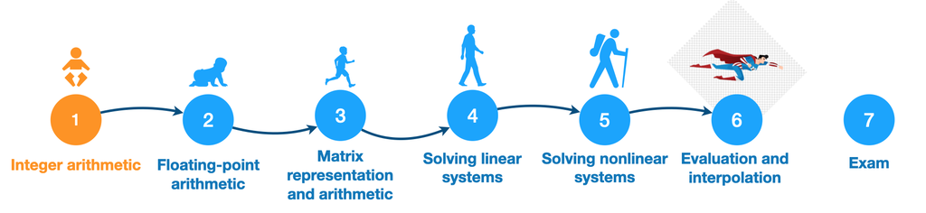

- Integer representation
  - Exercice 1: `convert_base`
- Integer addition
  - Exercice 2: `addition_base`
- Integer multiplication
  - Exercice 3: `multiplication_base`
  - Exercice 4: `karatsuba`
- Bitwise operations
  - Exercice 5
- Exercice 6

## 1. Integer representation

In Python, an integer is a element of $\mathbb{Z}$ which contains zero, positive and negative whole numbers without a fractional part. Python integers are interesting because they are not just, traditionally for programming languages such as C, 32-bit or 64-bit integers. Python integers are **arbitrary-precision integers**, also known as **bignums**. This means that they can be as large as we want (their sizes are only limited by the amount of available memory).

```python
n1 = 0
n2 = 12
n3 = -121
n4 = 123456789
n5 = 500000000000000000000000000000000000000000000000000
```

### 1.1. Some useful commands

You can **check the type** of an object with the command `type`

```python
print(type(n1))
print(type(n2))
print(type(n3))
print(type(n4))
print(type(n5))
```

```
<class 'int'>
<class 'int'>
<class 'int'>
<class 'int'>
<class 'int'>
```

Integers are represented (by default) in decimal but they can be represented in other radix like **binary**, **octal** or **hexadecimal**:

```python
print(0b11010001) # binary
print(0o117) # octal
print(0xE20F) # hexadecimal

type(0b11010001)
```

```
209
79
57871
```

```
int
```

Another way is using the command `int`:

```python
print(int("11010001", 2)) # binary
print(int("117", 8)) # octal
print(int("E20F", 16)) # hexadecimal

type(int("11010001", 2))
```

```
209
79
57871
```

```
int
```

We can convert an decimal integer easily in other radix representation:

```python
print(bin(209))
print(oct(79))
print(hex(57871))
```

```
0b11010001
0o117
0xe20f
```

### 1.2. Conversion algorithm

**Exercice 1:** define a function `convert_base(n, b)` which returns a string that converts a decimal integer `n` in a b-radix integer.

## 2. Integer addition

**Exercice 2:** define a function `addtion_base(A, B, b)` which returns a string that contains the b-radix addition of A and B.

## 3. Integer multiplication

Python uses $O(k^2)$ grade-school multiplication algorithm for small numbers, but for big numbers it uses $O(k^{1.59})$ Karatsuba algorithm.

**Exercice 3:** define a function `multiplication_base(A, B, b)` which returns a string that contains the b-radix addition of A and B using the grade-school method (see lecture 1).

**Exercice 4:** define a function `karatsuba(A, B, b)` which returns a string that contains the b-radix multiplication of A and B using the karatsuba method (see lecture 1).

## 4. Bitwise operations

**Exercice 5:** What do these functions do?

```python
def secret_function1(n):
    u = 0
    while n:
        n >>= 1
        u += 1
    return u

def secret_function2(n):
    v = 0
    z = 0
    while n:
        z += (n & 1)
        v += 1
        n >>= 1
    return(v, z)
```

**Exercice 6:** we consider the following integers `A` and `B`:

```python
A = 340282366920938463463374607431768211456
B = 4096
```

Compare "numerically" the time complexity of `multiplication_base(A, B, 10)`, `karatsuba(A, B, 10)` and a bitwise multiplication strategy. Comment.